# 数据科学报告

武碧璇

2020-03-27

Abstract

思考并完成老师所布置题目，回顾统计知识基础及增强利用R语言处理问题的能力。并且在书写报告的过程中，熟悉RMarkdown的使用方法。

# 真值与拟合值比较

使用蒙特卡洛方法对标准正态分布进行拟合。首先，根据标准正态分布的累积密度函数计算各`t`值下的真值。其次，利用标准正态分布的随机样本值，与`t`值进行比较构造计数函数，计算正态分布样本的拟合值。最后，比较不同`t`和`n`值下，蒙特卡洛方法的拟合程度。

1.计算不同`t`值的正态分布真值。

```r
> real = pnorm(tmatrix)
```

2.计算拟合值。将标准正态分布随机样本`X_i`和`t`代入下式求解拟合值。
$$\begin{aligned}
\hat\Phi(t) = & \frac{1}{n} \sum_{i=1}^n I(X_i \le t) \\
n \in & \{10^2, 10^3, 10^4\}
\end{aligned}$$

使用程序代码如下：

```r
> i = 1
> j = 1
> while (i <= 3) {
+     n = nmatrix[1, i]
+
+     while (j <= 9) {
+         t = tmatrix[1, j]
+         x = as.matrix(rnorm(n))
+         y = ifelse((x <= t), 1, 0)
+         end[i, j] = apply(y, 2, sum)/n
+         j = j + 1
+     }
+
+     j = 1
+     i = i + 1
+ }
```

3.生成表格，比较真值和拟合值。

```r
> tablevalue = rbind(tmatrix, real, end)
> col = as.matrix(c("t", "realvalue", "n=10^2", "n=10^3", "n=10^4"))
> table = cbind(col, tablevalue)
> knitr::kable(table, caption = "Comparison between real values and approximation",
+     format = "html")
```

Comparison between real values and approximation

| t | 0 | 0.67 | 0.84 | 1.28 | 1.65 | 2.32 | 2.58 | 3.09 | 3.72 |
| --- | --- | --- | --- | --- | --- | --- | --- | --- | --- |
| realvalue | 0.5 | 0.74857110490469 | 0.79954580673955 | 0.899727432045558 | 0.950528531966352 | 0.98982956133128 | 0.995059984242229 | 0.998999217523386 | 0.999900388611024 |
| n=10^2 | 0.53 | 0.78 | 0.76 | 0.92 | 0.94 | 0.99 | 1 | 1 | 1 |
| n=10^3 | 0.485 | 0.754 | 0.762 | 0.889 | 0.95 | 0.992 | 0.995 | 0.998 | 1 |
| n=10^4 | 0.4894 | 0.7537 | 0.7992 | 0.9034 | 0.9517 | 0.9905 | 0.9944 | 0.999 | 1 |

# 箱线图

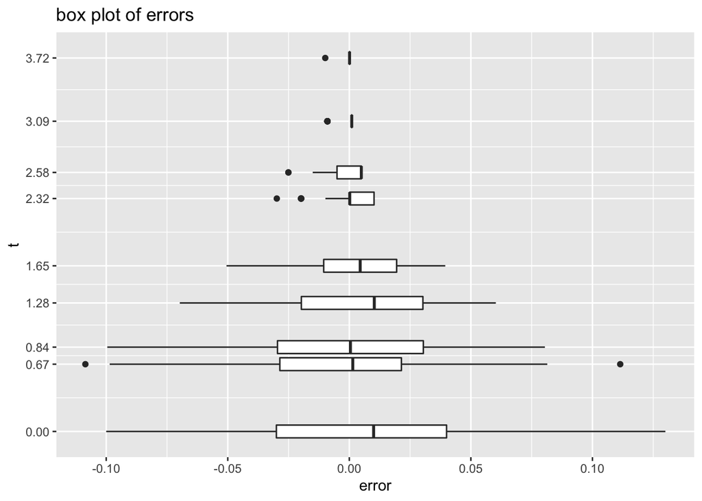

```r
> n = 100
>
> end = matrix(nrow = 100, ncol = 9)
> error = matrix(nrow = 100, ncol = 9)
>
> a = 1
> j = 1
> while (a <= 100) {
+     while (j <= 9) {
+         t = tmatrix[1, j]
+         x = as.matrix(rnorm(n))
+         y = ifelse((x <= t), 1, 0)
+         end[a, j] = apply(y, 2, sum)/n
+         error[a, j] = end[a, j] - real[1, j]
+         j = j + 1
+     }
+     j = 1
+     a = a + 1
+ }
>
> col1 = as.matrix(c(rep(0, 100), rep(0.67, 100), rep(0.84, 100), rep(1.28, 100), rep(1.65,
+     100), rep(2.32, 100), rep(2.58, 100), rep(3.09, 100), rep(3.72, 100)))
> col2 = as.matrix(c(error[, 1], error[, 2], error[, 3], error[, 4], error[, 5], error[,
+     6], error[, 7], error[, 8], error[, 9]))
> col = cbind(col1, col2)
>
> number = data.frame(col)
>
> library(ggplot2)
> box = ggplot(data = number, mapping = aes(x = X1, y = X2, group = X1))
> box + geom_boxplot() + coord_flip() + scale_x_continuous(breaks = c(0, 0.67, 0.84,
+     1.28, 1.65, 2.32, 2.58, 3.09, 3.72)) + labs(title = "box plot of errors", x = "t",
+     y = "error")
```

# 总结

收获：通过这次作业加深和巩固了R语言的使用，并且练习了RMarkdown的使用。

不足：1. 使用`>knite::xtable(number)`命令生成表格时，使用`>digits=`命令控制表格内数据小数位数无效。生成的表格太丑，需要进一步学习熟练。  
2. 由于RMarkdown和laTeX等软件对于中文的适配程度远不如英文，在加上自身熟练程度较差。knit一键生成的PDF和HTML文件丑。